# Graphing Relationships

```r
library(dplyr)
library(readr)
library(tidyverse)
library(ggplot2)
library(DT)
library(sf)
```

```r
State_Prez_vote <-read.csv("state_prez_vote.csv")
```

**Question 1**

a. Import that data into R. Create a new data frame by pivoting the data into long format, creating two new variables, one for year, and the other for either Democratic or Republican vote proportion.

```r
Long_data_frame <- State_Prez_vote |>
  pivot_longer(
    cols = matches("(obama|mccain|romney|clinton|trump|biden|harris)vote\\d+"),
    names_to = "candidate_year",
    values_to = "votes"
  ) |>
  separate(candidate_year, into = c("candidate", "year"), sep ="(?<=\\D)(?=\\d+)") |>
  mutate(
    party = case_match(candidate,
      c("obamavote", "clintonvote","bidenvote", "harrisvote")~ "Democratic",
      c("mccainvote","romneyvote","trumpvote") ~ "Republican"
    )
  )|>
  group_by(state,year) |>
  mutate(
    total_votes = sum(votes, na.rm =TRUE),
    vote_proportion = votes/total_votes
  )|>
  ungroup() |>
  select(state, year, party, candidate, vote_proportion) |>
  as_tibble()


print(Long_data_frame)
```

```
# A tibble: 510 × 5
   state   year  party      candidate   vote_proportion
   <chr>   <chr> <chr>      <chr>                 <dbl>
 1 Alabama 08    Democratic obamavote             0.391
 2 Alabama 08    Republican mccainvote            0.609
 3 Alabama 12    Democratic obamavote             0.388
 4 Alabama 12    Republican romneyvote            0.612
 5 Alabama 16    Democratic clintonvote           0.356
 6 Alabama 16    Republican trumpvote             0.644
 7 Alabama 20    Democratic bidenvote             0.371
 8 Alabama 20    Republican trumpvote             0.629
 9 Alabama 24    Republican trumpvote             0.654
10 Alabama 24    <NA>       Harrisvote            0.346
# ℹ 500 more rows
```

b. Create a clean table of summary statistics (means and standard deviations) for the 2016, 2020, and 2024 Trump proportions of the vote. Describe the overall pattern, in one sentence.

```r
trump_summary <- Long_data_frame |>
  filter(candidate == "trumpvote", year %in% c("16","20","24")) |>
  group_by(year) |>
  summarise(
    mean_vote_proportion = mean(vote_proportion,na.rm = TRUE),
    sd_vote_proportion = sd(vote_proportion, na.rm = TRUE)
  )|>
  arrange(year)
print(trump_summary)
```

```
# A tibble: 3 × 3
  year  mean_vote_proportion sd_vote_proportion
  <chr>                <dbl>              <dbl>
1 16                   0.520              0.128
2 20                   0.503              0.123
3 24                   0.525              0.121
```

- The pattern shows that the variation between states in 2016-2024 is stable and has not changes much.

c. Use the DT package (or something similar like reactable) to make an interactive table with either the Republican or Democratic proportions by state for the 5 elections.\

```r
Dem_table <- Long_data_frame |>
  filter(party == "Democratic") |>
  pivot_wider(
    names_from = year,
    values_from = vote_proportion
  ) |>
  drop_na('08') |>
  arrange(state)
datatable(
  Dem_table,
  option = list(pageLength = 10),
  caption = "Democratic Vote Proportions by State (2008-2024)",
  rownames = FALSE
)
```

| state | party | candidate | 08 | 12 | 16 | 20 |
| --- | --- | --- | --- | --- | --- | --- |
| Alabama | Democratic | obamavote | 0.3910909724642733 | 0.3878377146656229 |  |  |
| Alaska | Democratic | obamavote | 0.389352150834029 | 0.4268470951843963 |  |  |
| Arizona | Democratic | obamavote | 0.4568609928038368 | 0.4538661977629681 |  |  |
| Arkansas | Democratic | obamavote | 0.3982827938928274 | 0.3784559464877038 |  |  |
| California | Democratic | obamavote | 0.622784495915854 | 0.6187281116329663 |  |  |
| Colorado | Democratic | obamavote | 0.5455080765808366 | 0.5275010685600914 |  |  |
| Connecticut | Democratic | obamavote | 0.6131833824975418 | 0.587725774769071 |  |  |
| Delaware | Democratic | obamavote | 0.6263813864988855 | 0.5944695491927816 |  |  |
| District of Columbia | Democratic | obamavote | 0.9340076833341566 | 0.9258764920211752 |  |  |
| Florida | Democratic | obamavote | 0.514196600308993 | 0.5044225213936623 |  |  |

[output cut: 41 more lines]

**Question 2**

a. Using the data from 1, generate a vote swing scatter plot with the 2024 Trump proportion of the vote on the Y axis and the 2020 Trump proportion of the vote on the X axis, labeling the points with the state names, and adding a 45 degree line to the plot.

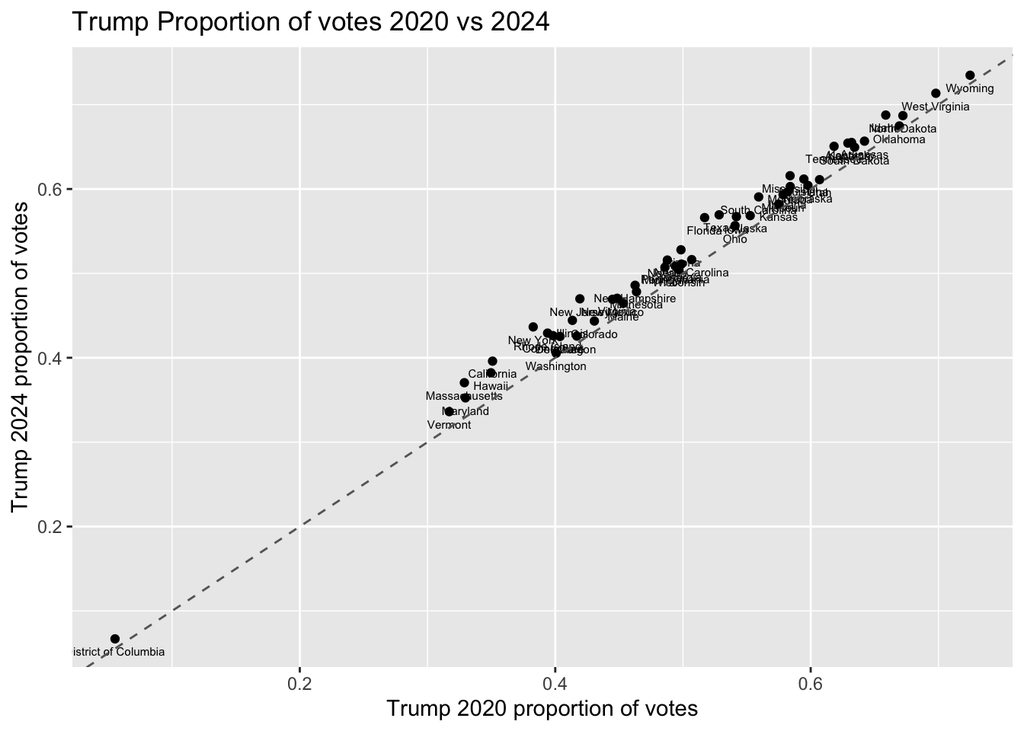

```r
trump_plot <- State_Prez_vote |>
  mutate(
    total_2020 = bidenvote20 + trumpvote20,
    total_2024 = trumpvote24 + Harrisvote24,
    trump_prop_2020 = trumpvote20 / total_2020,
    trump_prop_2024 = trumpvote24 / total_2024
  ) |>
  select(state, trump_prop_2020, trump_prop_2024) |>
  drop_na()

ggplot(trump_plot, aes(x = trump_prop_2020, y= trump_prop_2024)) +
  geom_point()+
  geom_text(aes(label = state), size = 2, vjust = 2) +
  geom_abline(slope = 1, intercept = 0, linetype = "dashed", color = "gray40") +
  labs(
    x = "Trump 2020 proportion of votes",
    y = "Trump 2024 proportion of votes",
    title = "Trump Proportion of votes 2020 vs 2024"
  )
```

b.Describe your graph. What is the overall pattern in the data? What purpose does the 45 degree line serve?

c. What challenges are created by labeling the states? Try labeling only some of the states, justifying your choice of states.

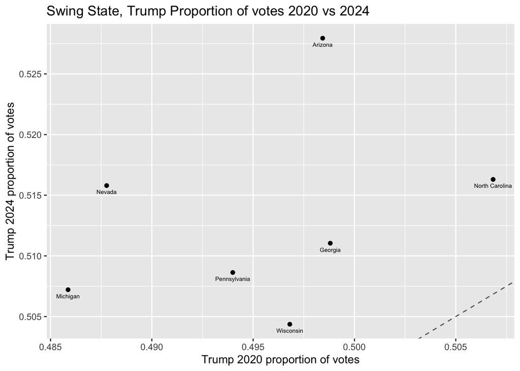

```r
trump_plot |>
  filter(state %in%  c("Arizona","Georgia","Michigan","Nevada","North Carolina","Pennsylvania","Wisconsin")) |>

  ggplot(aes(x = trump_prop_2020, y = trump_prop_2024)) +
  geom_point()+
  geom_text(aes(label = state), size = 2, vjust = 2) +
  geom_abline(slope = 1, intercept = 0, linetype = "dashed", color = "gray40") +
  labs(
    x = "Trump 2020 proportion of votes",
    y = "Trump 2024 proportion of votes",
    title = "Swing State, Trump Proportion of votes 2020 vs 2024"
  )
```

- Challenges created from labeling states are unreadable clustered areas. The names a blocking some of the other points.
- I chose to only show the swing states because these are the states that would most likely show variance between 2024 and 2020. While the other states are most like around that same portion of votes as 2020.

  e. Make a graph that omits Washington D.C. from the data. What effect does that have on the structure of the graph?

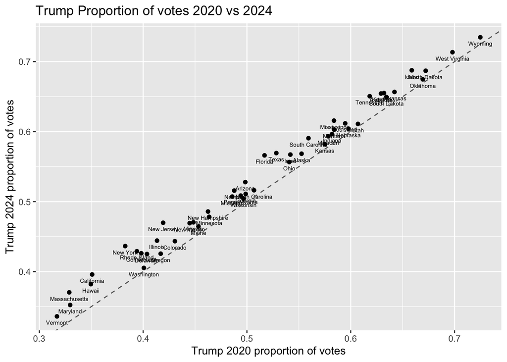

  ```r
  trump_plot <- State_Prez_vote |>
    mutate(
      total_2020 = bidenvote20 + trumpvote20,
      total_2024 = trumpvote24 + Harrisvote24,
      trump_prop_2020 = trumpvote20 / total_2020,
      trump_prop_2024 = trumpvote24 / total_2024
    ) |>
    filter(state != "District of Columbia") |>
    select(state, trump_prop_2020, trump_prop_2024) |>
    drop_na()

  ggplot(trump_plot, aes(x = trump_prop_2020, y= trump_prop_2024)) +
    geom_point()+
    geom_text(aes(label = state), size = 2, vjust = 2) +
    geom_abline(slope = 1, intercept = 0, linetype = "dashed", color = "gray40") +
    labs(
      x = "Trump 2020 proportion of votes",
      y = "Trump 2024 proportion of votes",
      title = "Trump Proportion of votes 2020 vs 2024"
    )
  ```

  - The effect shown on this graph is the spread of the states along the 45 degree line. DC has a very low proportion of Trump votes which elongated the line. Removing it reduces skew and makes the spread of the rest of the points easier to interpret.

**Question 3**

1. Using the same data but in long form, filter out Washington D.C., and generate a line plot for the 50 states from 2008 to 2024, graphing proportion Republican or proportion Democratic on the y-axis and year on the x-axis.

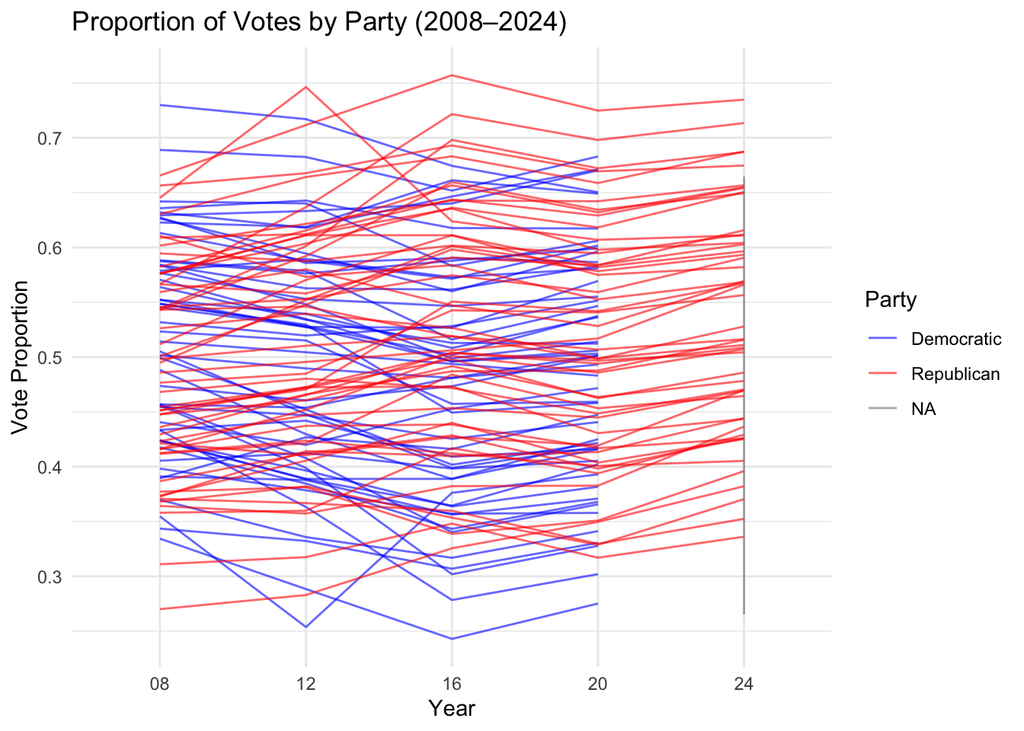

```r
filtered_data <- Long_data_frame |>
  filter(state !="District of Columbia")

ggplot(filtered_data, aes(x = year, y = vote_proportion, group = interaction(state, party), color = party )) +
  geom_line(alpha = 0.6) +
  scale_color_manual(values = c("Democratic"= "blue","Republican" = "red")) +
  labs(
    title = "Proportion of Votes by Party (2008–2024)",
    x = "Year",
    y = "Vote Proportion",
    color = "Party"
  ) +
  theme_minimal()
```

b. Choose a set of states that you find interesting, and emphasize those states using colors.

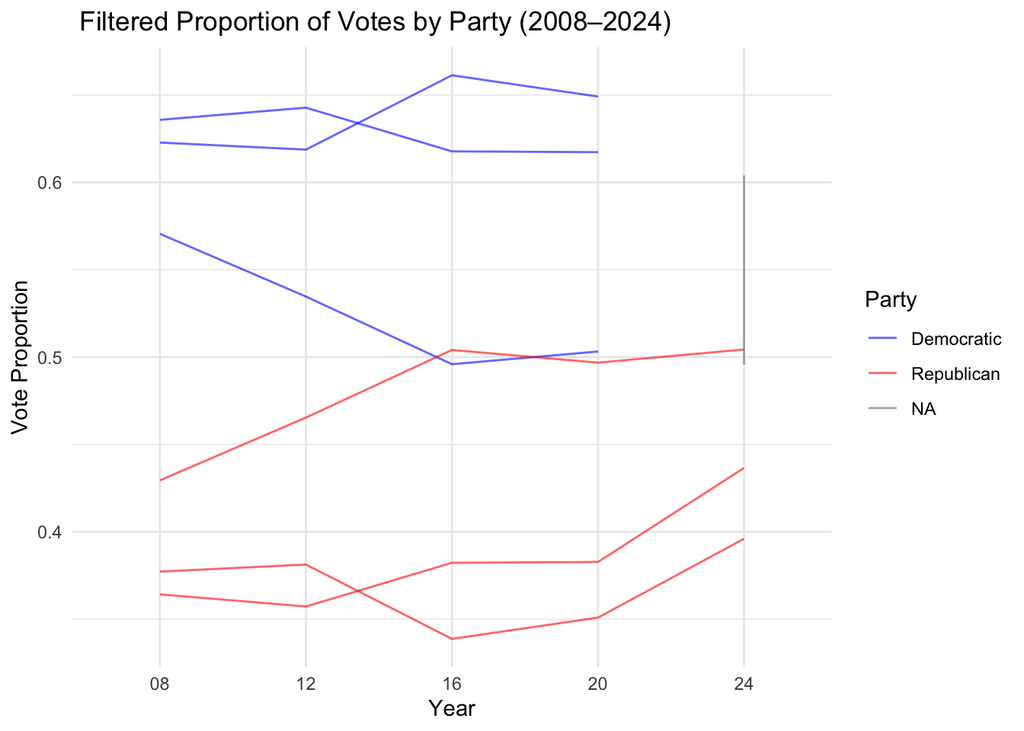

```r
filtered_data <- Long_data_frame |>
  filter(state %in% c("California","New York","Pennslyvania","Wisconsin","Arizonia", "Wisconsin"))

ggplot(filtered_data, aes(x = year, y = vote_proportion, group = interaction(state, party), color = party )) +
  geom_line(alpha = 0.6) +
  scale_color_manual(values = c("Democratic"= "blue","Republican" = "red")) +
  labs(
    title = " Filtered Proportion of Votes by Party (2008–2024)",
    x = "Year",
    y = "Vote Proportion",
    color = "Party"
  ) +
  theme_minimal()
```

c. Describe the overall patterns in the data over time. What central features are particularly noteworthy, and why?

d. What story are you telling with your use of color to highlight a set of states?

- I separated the republican and democratic votes proportions by red and blue colors to differ between the two. This difference will make the chart easier to read and see the variations between the two parties.

e.Remember that in section 7.1, Healy faceted his election graph by the four census regions. Generate a second graph structured as before, this time faceting by census region. Does faceting by census region make any of the patterns clearer? How so?

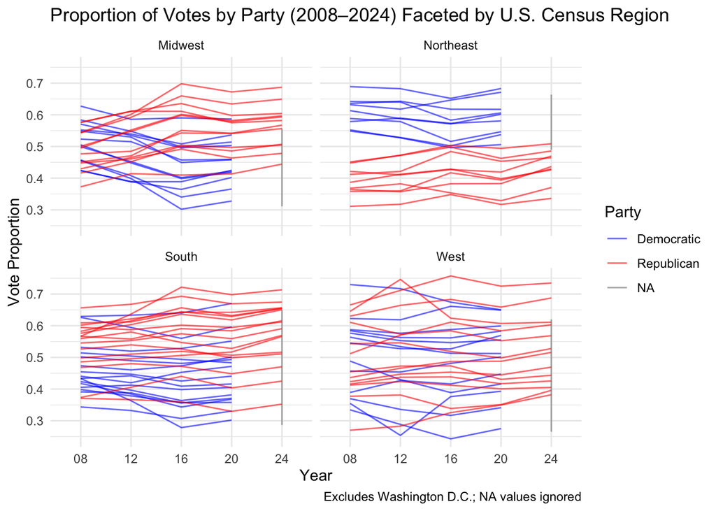

```r
Long_data_with_region <- Long_data_frame |>
  mutate(
    region = case_when(
      state %in% c("Maine", "New Hampshire", "Vermont", "Massachusetts", "Rhode Island", "Connecticut",
                   "New York", "New Jersey", "Pennsylvania") ~ "Northeast",
      state %in% c("Ohio", "Indiana", "Illinois", "Michigan", "Wisconsin", "Minnesota", "Iowa", "Missouri",
                   "North Dakota", "South Dakota", "Nebraska", "Kansas") ~ "Midwest",
      state %in% c("Delaware", "Maryland", "Virginia", "West Virginia", "Kentucky", "Tennessee", "North Carolina",
                   "South Carolina", "Georgia", "Florida", "Alabama", "Mississippi", "Arkansas", "Louisiana",
                   "Texas", "Oklahoma") ~ "South",
      state %in% c("Montana", "Idaho", "Wyoming", "Colorado", "New Mexico", "Arizona", "Utah", "Nevada",
                   "Washington", "Oregon", "California", "Alaska", "Hawaii") ~ "West",
      TRUE ~ NA_character_
    )
  )
Long_data_filtered <- Long_data_with_region |>
  filter(state != "District of Columbia")
ggplot(Long_data_filtered, aes(x = year, y = vote_proportion, group = interaction(state, party), color = party)) +
  geom_line(alpha = 0.6, na.rm = TRUE) +
  facet_wrap(~ region) +
  scale_color_manual(values = c("Democratic"= "blue","Republican" = "red")) +
  labs(
    title = "Proportion of Votes by Party (2008–2024) Faceted by U.S. Census Region",
    x = "Year",
    y = "Vote Proportion",
    color = "Party",
    caption = "Excludes Washington D.C.; NA values ignored"
  ) +
  theme_minimal()
```

- Yes faceting by region makes the patterns clearer compared to the graph with all 50 states. It also groups states with similar historical and cultural contexts.

**Question 4**

a.Generate a new variable that measures the change in the Trump vote proportion between 2024 and 2020. Left join that data to a simple features data frame for the United States, and make a thematic map of the state level vote change. What do you learn from this map that was harder to discern in the scatter plot in question 2?

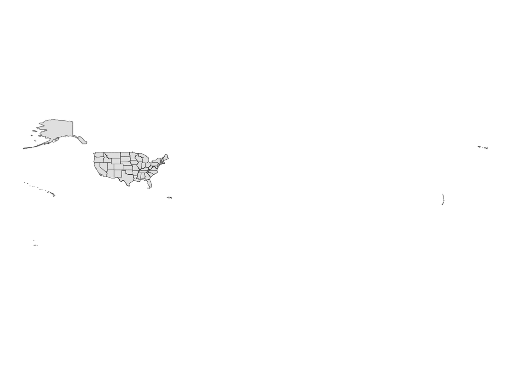

```r
US_Map <-st_read("tl_2021_us_state/tl_2021_us_state.shp")
ggplot(US_Map) +
  geom_sf() +
  theme_void()
```

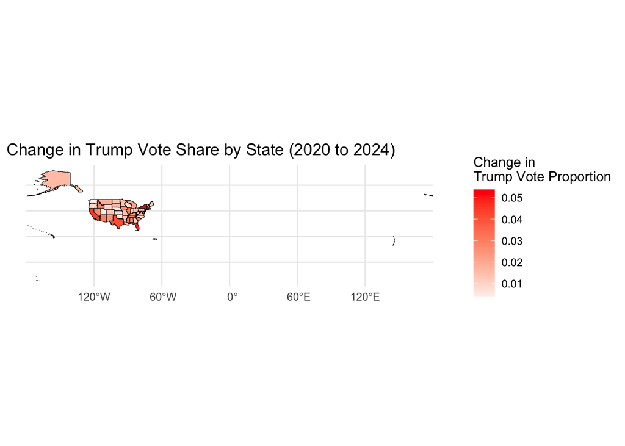

```r
trump_change <- State_Prez_vote |>
  mutate(
    total_2020 = trumpvote20 + bidenvote20,
    total_2024 = trumpvote24 + Harrisvote24,
    trump_prop_2020 = trumpvote20 / total_2020,
    trump_prop_2024 = trumpvote24 / total_2024,
    trump_change = trump_prop_2024 - trump_prop_2020
  ) |>
  select(state, trump_change)

us_map_data <- US_Map |>
  left_join(trump_change, by = c("NAME" = "state"))
ggplot(us_map_data) +
  geom_sf(aes(fill = trump_change), color = "black") +
  scale_fill_gradient2(
    low = "blue",  # Blue for decreases
    mid = "white",
    high = "red", # Red for increases
    midpoint = 0,
    name = "Change in\nTrump Vote Proportion"
  ) +
  labs(
    title = "Change in Trump Vote Share by State (2020 to 2024)"
  ) +
  theme_minimal()
```

- This map revels more geographical patterns and its easier to spot outliers